# Analyzing Notebook

Lam Vi Nam

2025-04-27

### Prepare Enviroment

```r
library(tidyverse)
library(dm)
library(lubridate)
library(forcats)
library(skimr)
library(treemap)
library(RColorBrewer)
```

```r
# read cleaned csv files
source("../code/customized_functions/read_files_by_path.R") # load user function for reading csv files
path <- "../data/cleaned" # directory path containing csv files
cleaned_tables <- read_files_by_path(directory_path = path)
```

```r
# unpack list to objects
list2env(cleaned_tables, envir = .GlobalEnv)
```

```r
# Draw all schema
dm_obj <- dm(activity_daily, calories_hourly, calories_minute, heartrate_second,
             intensities_hourly, intensities_minute, mets_minute, sleep_minute,
             steps_hourly, steps_minute, weight_NA)
dm_draw(dm_obj, view_type="all",column_types = TRUE)
```

[interactive chart not shown]

### Exploration Point 1.1: When Were Users Most Active By Hours?

> [Assumption] “TotalIntensity” is Fitbit’s way of quantifying the overall physical effort exerted during a given hour

##### *- Explore the table `intensities_hourly`*

```r
View(intensities_hourly)
glimpse(intensities_hourly)
```

```
Rows: 46,008
Columns: 4
$ Id               <dbl> 1503960366, 1503960366, 1503960366, 1503960366, 1503960366, 15039603…
$ ActivityHour     <dttm> 2016-03-12 00:00:00, 2016-03-12 01:00:00, 2016-03-12 02:00:00, 2016…
$ TotalIntensity   <dbl> 0, 0, 0, 0, 0, 0, 0, 0, 0, 1, 26, 49, 47, 20, 121, 129, 42, 20, 2, 3…
$ AverageIntensity <dbl> 0.000000, 0.000000, 0.000000, 0.000000, 0.000000, 0.000000, 0.000000…
```

##### *- Transformation*

```r
intensities_hourly_mutated <- intensities_hourly %>%
  mutate(activity_hour_extract = hour(ActivityHour))

intensities_hourly_mutated <- intensities_hourly_mutated %>%
  group_by(activity_hour_extract) %>%
  summarise(sum_total_intensity = sum(TotalIntensity)) %>%
  ungroup()
```

```r
# order the levels from 0 to 23 for plotting
intensities_hourly_mutated <- intensities_hourly_mutated %>%
  mutate(activity_hour_extract = factor(activity_hour_extract, levels = 0:23)) %>%
  mutate(activity_hour_extract = fct_rev(activity_hour_extract)) # Reverse the factor levels
```

##### *- Plotting*

- Horizontal bar chart

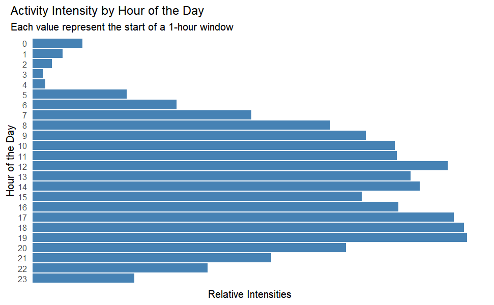

```r
# Create the horizontal bar chart
ggplot(intensities_hourly_mutated, aes(x = sum_total_intensity, y = activity_hour_extract)) +
  geom_col(fill = "steelblue") + # Use geom_col for pre-calculated sums, fill sets the bar color
  labs(
    title = "Activity Intensity by Hour of the Day",
    subtitle = "Each value represent the start of a 1-hour window",
    x = "Relative Intensities", # Set x-axis label to blank
    y = "Hour of the Day" # Label for the y-axis
  ) +
  theme_minimal() + # Start with a clean theme
  theme(
    panel.grid.major = element_blank(), # Remove major grid lines
    panel.grid.minor = element_blank(),  # Remove minor grid lines
    axis.text.x = element_blank(),   # Remove x-axis text (number marks)
    axis.text.y = element_text(margin = margin(r = -20)) # adjusts axis text margin
  )
```

> [Observations from the above chart]  
> There are three groups of time period: peak, amping up, and winding down.  
> - The most easily regconizable peak intensity period is from 17:00 to 20:00. The second one is from 12:00 to 15:00.  
> - Amping up periods are time windows that precede the peaks and see a relative increase in intensity levels. Those are: “8:00 to 12:00”, “15:00 to 17:00”.  
> - Winding down periods: the rest.  
> - Worth noticing window: “15:00 to 17:00” (because it’s both amping up and winding down).

### Exploration Point 1.2: When Was the Peak of Calorie Burned by Hours?

> [Assumption]  
> - `calories_hourly$Calories` refers to calories burned.

##### *- Explore the table `calories_hourly`*

```r
View(calories_hourly)
glimpse(calories_hourly)
```

##### *- Transformation*

- Extract the hour from `calories_hourly$ActivityHour`
- Sum `calories_hourly$Calories` up by hour -> `hour_only`
- Factor `hour_only` for ordering on the y-axis

```r
hourly_calories_summary <- calories_hourly %>%
  # Ensure ActivityHour is in datetime format if it's not already
  # mutate(ActivityHour = as.POSIXct(ActivityHour)) %>% # Uncomment and adjust format if needed
  mutate(hour_only = hour(ActivityHour)) %>% # Extract the hour (0-23)
  group_by(hour_only) %>% # Group by the extracted hour
  summarise(calories_sum = sum(Calories, na.rm = TRUE), .groups = 'drop') %>%
  ungroup()
# We order the levels from 0 to 23
hourly_calories_summary <- hourly_calories_summary %>%
  mutate(hour_only = factor(hour_only, levels = 0:23)) %>%
  mutate(hour_only = fct_rev(hour_only)) # Reverse the factor levels so 0 is at the top
```

##### *- Plotting*

- Bar chart

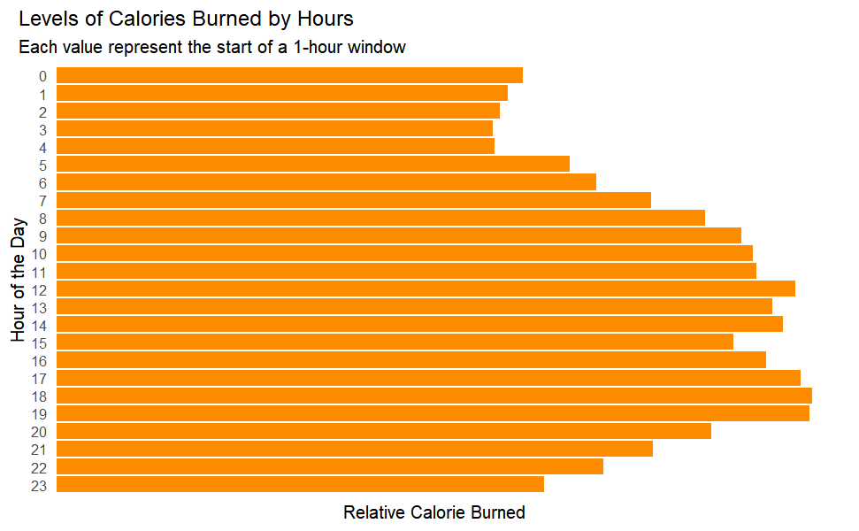

```r
# Create the bar chart
ggplot(hourly_calories_summary, aes(x = calories_sum, y = hour_only)) +
  geom_col(fill = "darkorange") + # Use geom_col for pre-calculated sums
  labs(
    title = "Levels of Calories Burned by Hours", # Add a title
    subtitle = "Each value represent the start of a 1-hour window",
    x = "Relative Calorie Burned", # Label for the x-axis (now calories)
    y = "Hour of the Day" # Label for the y-axis (now hour)
  ) +
  theme_minimal() + # Use a clean theme
  theme(
    # Adjust theme elements for a horizontal bar chart
    panel.grid.major.y = element_blank(),
    panel.grid.minor.y = element_blank(),
    panel.grid.major.x = element_blank(),
    panel.grid.minor.x = element_blank(),
    axis.text.x = element_blank(),   # Remove x-axis text (number marks)
    axis.text.y = element_text(margin = margin(r = -20)) # adjusts axis text margin
  )
```

> [Observations from the above chart]  
> - The calorie-burned pattern matchs the pattern of intensity, where peak calorie-burned period is from 17:00 to 20:00. The second one is from 12:00 to 15:00.  
> - The calorie burned is quite noticeable from 21:00 to 8:00, considering the relatively low intensity happened during that time window.

### Exploration Point 2:

### 2.1 How Much Time was Spent for Active Activities

##### *- Explore the table `activity_daily`*

```r
View(activity_daily)
glimpse(activity_daily)
```

##### *- Transformation*

- Aggregate by Id, calculate sums, count days, and calculate percentages
- Transform to long format for plotting purpose

```r
activity_aggregated <- activity_daily %>%
  # Group the data by the 'Id' column
  group_by(Id) %>%
  # Summarise the minutes for each Id and count the number of days
  summarise(
    sum_VeryActiveMinutes = sum(VeryActiveMinutes),
    sum_FairlyActiveMinutes = sum(FairlyActiveMinutes),
    sum_LightlyActiveMinutes = sum(LightlyActiveMinutes),
    no_days = n() # Count the number of rows for each Id (assuming each row is a day)
  ) %>%
  # Calculate total active minutes and the requested percentages
  mutate(
    total_active_minutes = sum_VeryActiveMinutes + sum_FairlyActiveMinutes + sum_LightlyActiveMinutes,

    # Calculate percentage of each activity type over the total active minutes for that Id
    very_active_percent = (sum_VeryActiveMinutes / total_active_minutes) * 100,
    fairly_active_percent = (sum_FairlyActiveMinutes / total_active_minutes) * 100,
    lightly_active_percent = (sum_LightlyActiveMinutes / total_active_minutes) * 100,

    # Calculate percentage of total active minutes over the total possible minutes (days * 1440)
    active_percent_daily = (total_active_minutes / (no_days * 1440)) * 100
  ) %>%
  # Ungroup the data frame after summarising and mutating
  ungroup()
```

```r
activity_pivot_long <- activity_aggregated %>%
  select(Id, very_active_percent, fairly_active_percent, lightly_active_percent, active_percent_daily) %>%
  pivot_longer(
    cols = c(very_active_percent, fairly_active_percent, lightly_active_percent),
    names_to = "type_of_active_raw", # Temporary column for original names
    values_to = "type_of_active_percent"   # New column for the percentage values
  ) %>%
  # Create the 'type_of_active' column with desired labels and order
  mutate(
    type_of_active = case_when(
      type_of_active_raw == "lightly_active_percent" ~ "Lightly Active",
      type_of_active_raw == "fairly_active_percent" ~ "Fairly Active",
      type_of_active_raw == "very_active_percent" ~ "Very Active",
      TRUE ~ type_of_active_raw # Should not happen with these columns
    )
  ) %>%
  # Set the factor levels for 'type_of_active' in the desired order
  mutate(
    type_of_active = factor(type_of_active, levels = c("Lightly Active", "Fairly Active", "Very Active"))
  ) %>%
  select(-type_of_active_raw) # Remove the raw column
```

##### *- Plotting*

- Facet scatter plot

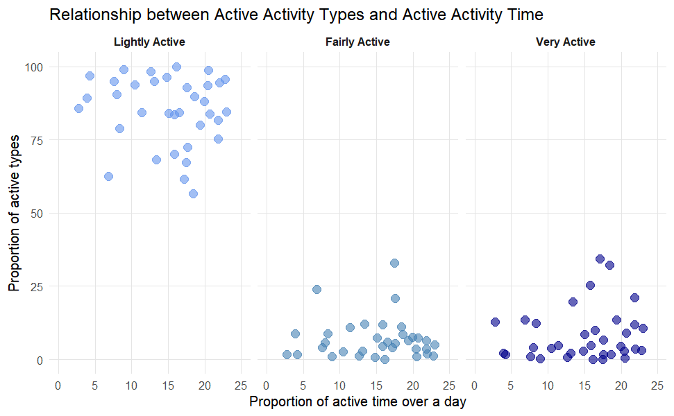

```r
# Create the correlation plot with specified facet order and coloring by group
ggplot(activity_pivot_long, aes(x = active_percent_daily, y = type_of_active_percent, color = type_of_active)) +
  geom_point(alpha = 0.6, size = 3) + # Use points for a scatter plot, alpha for transparency
  scale_x_continuous(limits = c(0, 25)) + # control the x-axis limits
  facet_wrap(~ type_of_active) + # Facet by type_of_active (now ordered)
  # Manually set colors for each activity type
  scale_color_manual(
    values = c(
      "Lightly Active" = "cornflowerblue",  # Lighter shade for Lightly Active
      "Fairly Active" = "steelblue",   # Medium shade for Fairly Active
      "Very Active" = "darkblue"       # Darker shade for Very Active
    ),
    guide = "none" # Remove the legend for color since it's faceted by type already
  ) +
  labs(
    title = "Relationship between Active Activity Types and Active Activity Time",
    x = "Proportion of active time over a day",
    y = "Proportion of active types"
  ) +
  theme_minimal() + # Clean theme
  theme(
    panel.grid.major = element_line(color = "grey90", size = 0.5), # Keep light grid lines for readability within facets
    panel.grid.minor = element_blank(), # Remove minor grid lines
    strip.text = element_text(face = "bold"), # Make facet titles bold
    legend.position = "none" # no color legend
  )
```

> [Observations from the above chart]  
> - There’s no correlation between active types and daily time spent for active activities.
- Histogram

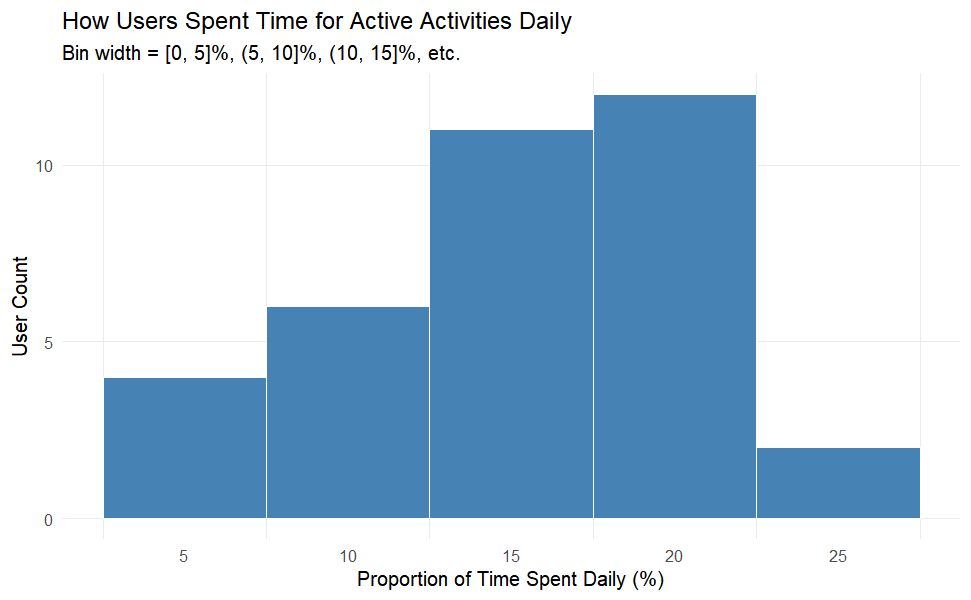

```r
# Create the histogram of active_percent_daily
ggplot(activity_aggregated, aes(x = active_percent_daily)) +
  geom_histogram(binwidth = 5, fill = "steelblue", color = "white") + # Create the histogram bars
  scale_x_continuous(
    breaks = seq(0, 25, by = 5)
  ) +
  scale_y_continuous(
    breaks = seq(0, 25, by = 5)
  ) +
  labs(
    title = "How Users Spent Time for Active Activities Daily",
    subtitle = "Bin width = [0, 5]%, (5, 10]%, (10, 15]%, etc.",
    x = "Proportion of Time Spent Daily (%)",
    y = "User Count" # Label for the y-axis
  ) +
  theme_minimal() + # Use a clean theme
  theme(
    panel.grid.major.x = element_blank(),  # Remove minor vertical grid lines
    panel.grid.minor.y = element_blank()  # Remove minor vertical grid lines
  )
```

> [Observations from the above chart]  
> - The amount of time spent for active activities daily is equal to 15% on average.  
> - The range from 10% to 20% daily time spent for active activities is the most popular.

### 2.2 When Users Were Active, Which Level of Activeness Did Users Spend Time For the Most?

##### *- Transformation*

```r
# Calculate the mean percentage for each activity type and prepare data for stacking and labels
for_stacked_bar <- activity_pivot_long %>%
  # Group by the activity type
  group_by(type_of_active) %>%
  # Summarise to calculate the mean percentage for each group
  summarise(
    MeanPercentage = mean(type_of_active_percent, na.rm = TRUE)
  ) %>%
  ungroup() %>% # Ungroup the data
  # Arrange by type_of_active factor levels for correct stacking
  arrange(type_of_active) %>%
  # Calculate the position for the text labels within the stacked bars
  # This requires calculating cumulative sums
  mutate(
    # Calculate the cumulative sum of percentages
    cumulative_percentage = cumsum(MeanPercentage),
    # Calculate the text position as the midpoint of each segment
    text_position = MeanPercentage / 2 + lag(cumulative_percentage, default = 0)
  )
```

##### *- Plotting*

- Stacked bar chart

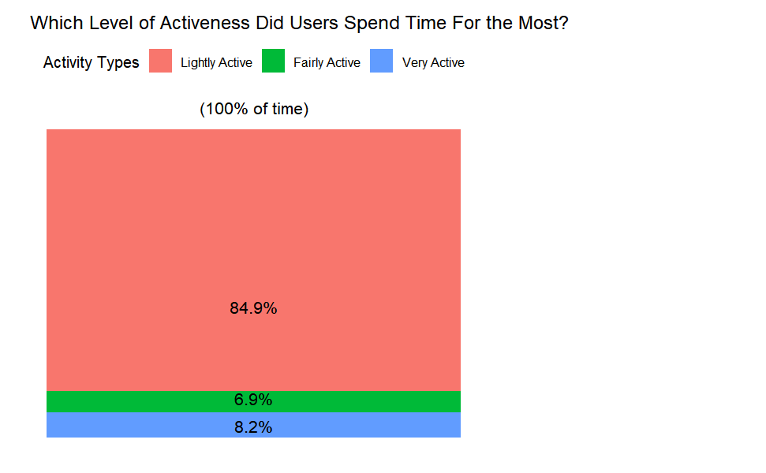

```r
# Create the base stacked bar chart
stacked_bar_chart_annotate <- ggplot(for_stacked_bar, aes(x = "", y = MeanPercentage, fill = type_of_active)) +
  geom_bar(stat = "identity", width = 0.5) + # Create the stacked bar
  labs(
    title = "Which Level of Activeness Did Users Spend Time For the Most?", # Add a title
    x = "", # Remove x-axis label
    y = "Average Percentage", # Y-axis label
    fill = "Activity Types" # Title for the legend
  ) +
  theme_minimal() + # Use a clean theme
  theme(
    axis.title.x = element_blank(), # Remove x-axis title
    axis.text.x = element_blank(), # Remove x-axis text (since it's a single bar)
    axis.title.y = element_blank(),
    axis.text.y = element_blank(),
    panel.grid.major = element_blank(), # Remove major grid lines
    panel.grid.minor = element_blank(), # Remove minor grid lines
    plot.title = element_text(hjust = 0.6),# Center the plot title
    legend.position = "top", # Position the legend
    plot.margin = margin(10, 10, 10, -170, "pt") # left-aligned
  )

# Add data labels using annotate() for manual adjustment
# You will need to manually adjust the 'y' coordinate for each label
stacked_bar_chart_annotate <- stacked_bar_chart_annotate +
  # Label for Lightly Active
  annotate(
    "text",
    x = "", # X-position (center of the bar)
    y = for_stacked_bar$text_position[for_stacked_bar$type_of_active == "Lightly Active"], # Calculated Y-position
    label = paste0(round(for_stacked_bar$MeanPercentage[for_stacked_bar$type_of_active == "Lightly Active"], 1), "%"), # Formatted percentage
    color = "black", # Label color (adjust as needed for visibility)
    size = 4 # Label size
    # Use vjust and hjust here if further fine-tuning is needed
  ) +
  # Label for Fairly Active
  annotate(
    "text",
    x = "", # X-position (center of the bar)
    y = for_stacked_bar$text_position[for_stacked_bar$type_of_active == "Fairly Active"], # Calculated Y-position
    label = paste0(round(for_stacked_bar$MeanPercentage[for_stacked_bar$type_of_active == "Fairly Active"], 1), "%"), # Formatted percentage
    color = "black", # Label color (adjust as needed for visibility)
    size = 4, # Label size
    vjust = 19
    # Use vjust and hjust here if further fine-tuning is needed
  ) +
  # Label for Very Active
  annotate(
    "text",
    x = "", # X-position (center of the bar)
    y = for_stacked_bar$text_position[for_stacked_bar$type_of_active == "Very Active"], # Calculated Y-position
    label = paste0(round(for_stacked_bar$MeanPercentage[for_stacked_bar$type_of_active == "Very Active"], 1), "%"), # Formatted percentage
    color = "black", # Label color (adjust as needed for visibility)
    size = 4, # Label size
    vjust = 23
    # Use vjust and hjust here if further fine-tuning is needed
  ) +
  # Add the "100%" note inside the plot
  annotate(
    "text",
    x = "", # X-position (center of the bar)
    y = 105, # Y-position (adjust this value to place the note correctly)
    label = "(100% of time)",
    vjust = 0, # Vertical justification
    hjust = 0.5, # Horizontal justification
    size = 4,
    color = "black"
  )
stacked_bar_chart_annotate
```

> [Observations from the above chart]  
> - The lightly active activities occupies a major proportion (84.9%), dominating the two other types of active activites.

### Exploration Point 3: How Many Hours per Day Did Users Sleep

##### *- Explore the table `sleep_minute`*

```r
View(sleep_minute)
glimpse(sleep_minute)
```

##### *- Transformation*

- From the `sleep_minute` table, extract date only from the date time column `date`, then group the `Id` and `date_only` columns and aggregate (sum) the `value` column to have `sleep_minute_daily` -> result in `aggregated_sleep_minute` table
- From `aggregated_sleep_minute` table, group `Id` column then take the average of `sleep_minute_daily` -> result in `mean_sleep_minute` table

```r
# Step 1 & 2: Extract date and group by Id and date, then aggregate (sum) sleep minutes daily
# Resulting table: aggregated_sleep_minute
aggregated_sleep_minute <- sleep_minute %>%
  # Ensure the 'date' column is in datetime format if it's not already
  # mutate(date = as.POSIXct(date)) %>% # Uncomment and adjust format if needed
  mutate(date_only = as.Date(date)) %>% # Extract date only
  group_by(Id, date_only) %>% # Group by Id and the extracted date
  summarise(sleep_minute_daily = sum(value, na.rm = TRUE), .groups = 'drop') %>% # Sum the sleep minutes daily, .groups = 'drop' removes grouping
  ungroup() # Ensure ungrouping (redundant with .groups='drop' but good practice)

# Step 3 & 4: Group by Id from aggregated_sleep_minute and take the average of sleep_minute_daily
# Resulting table: mean_sleep_minute
mean_sleep_minute <- aggregated_sleep_minute %>%
  group_by(Id) %>% # Group by Id
  summarise(mean_sleep_minute = mean(sleep_minute_daily, na.rm = TRUE), .groups = 'drop') %>% # Calculate the average daily sleep minutes per Id
  ungroup() # Ensure ungrouping

# Print the resulting tables (optional, for verification)
# print("Aggregated Daily Sleep Minutes:")
# print(aggregated_sleep_minute)
# print("Mean Daily Sleep Minutes per User:")
# print(mean_sleep_minute)
```

##### *- Plotting*

- Histogram

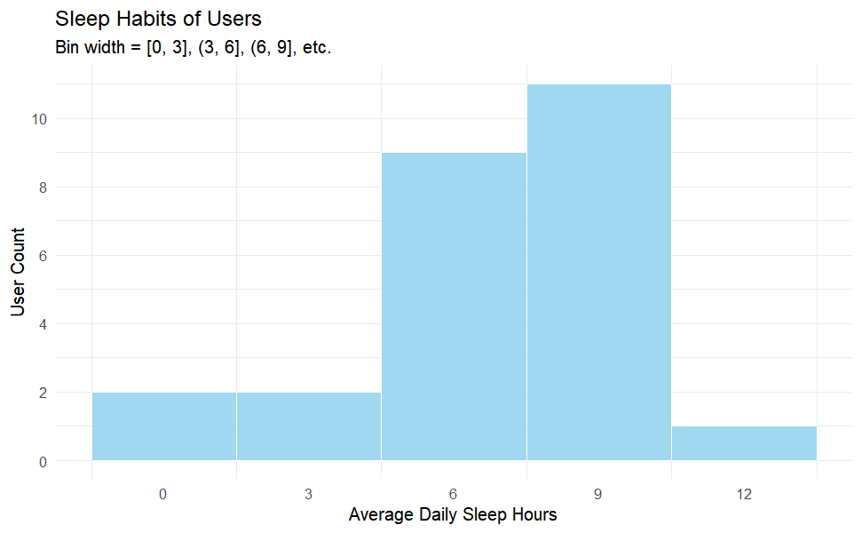

```r
ggplot(mean_sleep_minute, aes(x = mean_sleep_minute/60)) +
  geom_histogram(binwidth = 3
                 , fill = "skyblue", color = "white", alpha = 0.8) +
  scale_x_continuous(breaks = seq(0, 15, by = 3)) +
  scale_y_continuous(breaks = seq(0, 30, by = 2)) +
  labs(
    title = "Sleep Habits of Users",
    subtitle = "Bin width = [0, 3], (3, 6], (6, 9], etc.",
    x = "Average Daily Sleep Hours",
    y = "User Count"
  ) +
  theme_minimal() +
  theme(
    panel.grid.major.x = element_blank(), # Remove major vertical grid lines
  )
```

### Exploration Point 4:

### 4.1 How Far Did Users Walk/Run Daily

> [Assumption]  
> - Values in the column `TotalDistance` are kilometers (km).  
> - TotalDistance is Fitbit’s estimates of the real-world distance the user covered (physical ground).

##### *- Explore the table `activity_daily`*

```r
View(activity_daily)
glimpse(activity_daily)
```

##### *- Transformation*

```r
activity_daily_avg <- activity_daily %>%
  group_by(Id) %>%
  summarise(AverageTotalDistance = mean(TotalDistance, na.rm = TRUE)) %>%
  mutate(Id = as.character(Id))
```

##### *- Plotting*

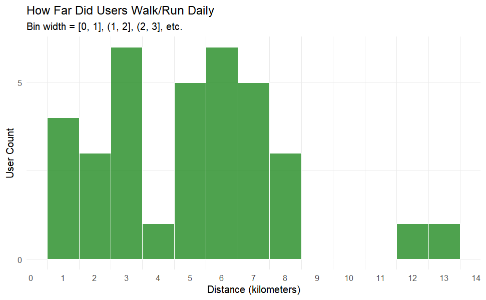

```r
ggplot(activity_daily_avg, aes(x = AverageTotalDistance)) +
  geom_histogram(binwidth = 1
                 , fill = "forestgreen", color = "white", alpha = 0.8) + # Adjust binwidth as needed (e.g., 1 unit)
  scale_y_continuous(breaks = seq(0, 20, by = 5)) +
  scale_x_continuous(breaks = seq(0, 20, by = 1)) +
  labs(
    title = "How Far Did Users Walk/Run Daily",
    subtitle = "Bin width = [0, 1], (1, 2], (2, 3], etc.",
    x = "Distance (kilometers)",
    y = "User Count"
  ) +
  theme_minimal() +
  theme(
    panel.grid.major.x = element_blank(), # Remove major vertical grid lines
  )
```

> [Observations from the above chart]  
> - There two groups of users: below 4-km enjoyers and above 4-km enjoyers.  
> - Anything above the 9 km milestone is not popular.

### 4.2 How Intense Were the Distance-based Exercises

> [Assumption]  
> - LightActiveDistance: includes leisurely walking or other low-effort movements.  
> - ModeratelyActiveDistance: includes activities like brisk walking, moderate cycling, or other activities that elevate your heart rate and breathing somewhat but where you can still hold a conversation.  
> - VeryActiveDistance: includes activities like running, high-intensity interval training (HIIT), or other strenuous efforts where you are breathing heavily and finding it difficult to speak in full sentences.

##### *- Transformation*

- Calculate the proportion of summed up distance groups
- Then transform to long format for treemap plot

```r
# Calculate the sum of each activity distance column across all rows
distance_sums <- activity_daily %>%
  summarise(
    SumVeryActiveDistance = sum(VeryActiveDistance, na.rm = TRUE),
    SumModeratelyActiveDistance = sum(ModeratelyActiveDistance, na.rm = TRUE),
    SumLightActiveDistance = sum(LightActiveDistance, na.rm = TRUE),
    SumSedentaryActiveDistance = sum(SedentaryActiveDistance, na.rm = TRUE)
  )
# This sum will be used as the denominator for calculating proportions
sum_of_components <- distance_sums$SumVeryActiveDistance +
                     distance_sums$SumModeratelyActiveDistance +
                     distance_sums$SumLightActiveDistance +
                     distance_sums$SumSedentaryActiveDistance

# Prepare data frame for treemap plot
# Need to use pivot_longer to transform into long format
# Calculate the percentage here, which will be used in the label
treemap_data <- distance_sums %>%
  pivot_longer(
    cols = everything(), # Select all columns (the sum columns)
    names_to = "ActivityTypeRaw", # Temporary column for the original column names
    values_to = "TotalDistanceSum" # New column for the total distance sum for each type
  ) %>%
  # Clean up the ActivityType names and create the final ActivityType column
  mutate(
    ActivityType = case_when(
      ActivityTypeRaw == "SumVeryActiveDistance" ~ "Very Active",
      ActivityTypeRaw == "SumModeratelyActiveDistance" ~ "Moderately Active",
      ActivityTypeRaw == "SumLightActiveDistance" ~ "Light Active",
      ActivityTypeRaw == "SumSedentaryActiveDistance" ~ "Sedentary Active",
    ),
    # Calculate the percentage of each activity type relative to the sum of components
    # This percentage is calculated BEFORE plotting and added as a column
    Percentage = round((TotalDistanceSum / sum_of_components) * 100, 1)
    ) %>%
  select(ActivityType, Percentage)
# Pre-compile labels for the plot
treemap_data <- treemap_data %>%
  mutate(
    Label = paste(
      ActivityType," Distance",
      "\n",
      Percentage, "%",
      sep = ""
    )
  )
```

##### *- Plotting*

- Treemap

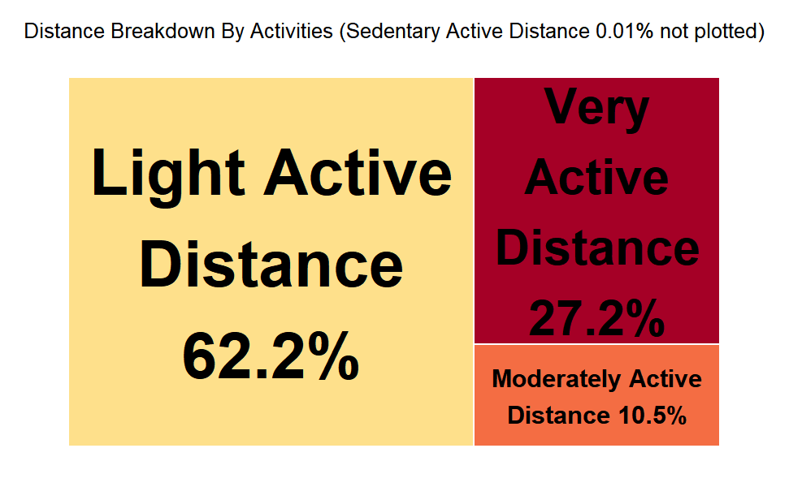

```r
# Custom color assignments (reversed RdYlGn with manual selection)
custom_colors <- brewer.pal(11, "RdYlGn")[c(5, 3, 11, 1)]  # Red, orange, light orange, green
names(custom_colors) <- c("Very Active", "Moderately Active", "Light Active", "Sedentary Active")

# Ensure your treemap_data is ordered correctly (critical for color matching)
treemap_data <- treemap_data %>%
  mutate(ActivityType = factor(ActivityType, levels = names(custom_colors))) %>%
  arrange(ActivityType)

# Create treemap with manual colors
treemap(
  treemap_data,
  index = "Label",          # Use precomputed labels
  vSize = "Percentage",     # Box sizes
  title = "Distance Breakdown By Activities (Sedentary Active Distance 0.01% not plotted)",
  fontsize.title = 14,
  fontsize.labels = 12,
  fontcolor.labels = "black",
  border.col = "white",
  palette = custom_colors,             # Color palette
  inflate.labels = TRUE           # Ensure labels are visible
)
```

> [Observations from the above chart]  
> - Lightly active level has a 62.2% share of the total distance.  
> - Moderately active (10.5%) and very active (27.2%) levels are also noticeable.  
> - Sedentary active level (0.01%) is minuscule.

> [Note] This is an [R Markdown](http://rmarkdown.rstudio.com) Notebook. When you execute code within the notebook, the results appear beneath the code. The preview shows you a rendered HTML copy of the contents of the editor. Consequently, unlike *Knit*, *Preview* does not run any R code chunks. Instead, the output of the chunk when it was last run in the editor is displayed. When you save the notebook, an HTML file containing the code and output will be saved alongside it (click the *Preview* button or press *Ctrl+Shift+K* to preview the HTML file).